# Hue-mans and Color: What We Say When We’re Not Sure

Author

Greg Hernandez

Published

September 24, 2025

## Introduction

```r
library(tidyverse)
library(gt)
library(readxl)
color_survey <- read_csv("color_survey.csv")
```

For this project I will be looking at responses that are trying to be more precise but can’t find the exact color. By this I mean responses about colors that have an **“ish”** in them or responses like **“Bluish Green”** or **“Brownish red”**.

## Cleaning and `NA`’s

I will start by looking at the `NA`’s in this data set and decide what to do with them.

```r
color_survey |>
  summarise_all(~ sum(is.na(.))) |>
  glimpse()
```

```
Rows: 1
Columns: 11
$ color        <int> 0
$ r            <int> 0
$ g            <int> 0
$ b            <int> 0
$ user_id      <int> 0
$ timestamp    <int> 0
$ response     <int> 1159
$ monitor      <int> 0
$ y_chromosome <int> 50237
$ colorblind   <int> 76212
$ spam_prob    <int> 0
```

Here we can see that the only columns with `NA`’s are the `response`, `y_chromosome`, and the `colorblind` columns.

```r
na_color <- color_survey |>
  filter(if_any(everything(), is.na))

glimpse(na_color)
```

```
Rows: 96,896
Columns: 11
$ color        <chr> "#2bc83b", "#3a6c2f", "#ede39e", "#47eaaf", "#fa6a84", "#…
$ r            <dbl> 43, 58, 237, 71, 250, 49, 14, 108, 104, 24, 91, 80, 82, 1…
$ g            <dbl> 200, 108, 227, 234, 106, 121, 173, 47, 14, 166, 146, 32, …
$ b            <dbl> 59, 47, 158, 175, 132, 177, 199, 5, 15, 157, 85, 189, 90,…
$ user_id      <dbl> 22, 22, 22, 48, 48, 48, 48, 48, 48, 48, 48, 48, 48, 38, 3…
$ timestamp    <dbl> 1267423281, 1267423303, 1267423308, 1267423638, 126742365…
$ response     <chr> "green", "forest green", "beige", "seafoam green", "lipst…
$ monitor      <chr> "LCD", "LCD", "LCD", "LCD", "LCD", "LCD", "LCD", "LCD", "…
$ y_chromosome <dbl> NA, NA, NA, NA, NA, NA, NA, NA, NA, NA, NA, NA, NA, 1, 1,…
$ colorblind   <dbl> NA, NA, NA, NA, NA, NA, NA, NA, NA, NA, NA, NA, NA, 0, 0,…
$ spam_prob    <dbl> 0.0004188106, 0.0004188106, 0.0004188106, 0.0003314786, 0…
```

I am suspecting that people who are inputting more than 1 response are contributing at least to some of the `NA`’s.

```r
na_color |>
  group_by(user_id) |>
  summarise(resp_w_na = n()) |>
  arrange(desc(resp_w_na)) |>
  slice_max(resp_w_na, n = 10) |>
  gt() |>
  tab_header(title = "Top 5 Users with Most Missing Responses") |>
  cols_label( user_id = "User ID",
    resp_w_na = "# of NA Responses")
```

| User ID | # of NA Responses |
| --- | --- |
| 124302 | 700 |
| 78909 | 387 |
| 77267 | 352 |
| 103069 | 339 |
| 8022 | 328 |
| 95845 | 276 |
| 100307 | 272 |
| 100191 | 268 |
| 32321 | 260 |
| 32562 | 212 |
| 126368 | 212 |

It looks like the top users do have more `NA`’s

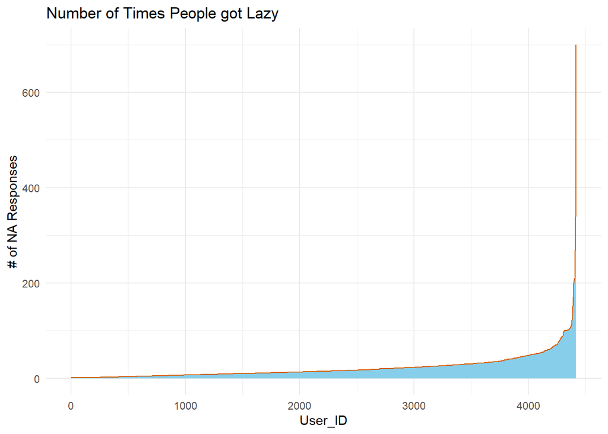

```r
na_counts <- na_color |>
  count(user_id, name = "resp_w_na")

na_counts |>
  arrange(resp_w_na) |>
  mutate(index = row_number()) |>
  ggplot(aes(x = index,
             y = resp_w_na)) +
  geom_ribbon(aes(ymin = 0,
                  ymax = resp_w_na),
              fill = "skyblue") +
  geom_line(color = "#D55E00") +
  labs(x = "User_ID",
    y = "# of NA Responses",
    title = "Number of Times People got Lazy") +
  theme_minimal()
```

I can confirm that from this plot, a lot of the `NA`’s come from top users which leads me to believe that they aren’t necessarily spam responses but they just got tired of filling in the same fields and chose not to re-enter their information for every color.

```r
color_survey_clean <- color_survey |>
  group_by(user_id) |>
  fill(y_chromosome, colorblind, .direction = "downup") |>
  ungroup() |>
  filter(!is.na(response))
```

I learned about the fill command where if some `user_id` put their information from before but got lazy and stopped inputting it, then their initial input for `y_chromosome` and `colorblind` would be transferred for the other observations. If they never put that information in the first place I will leave it in until I see a need to change that. But there are some observations where the `response`has an `NA` so I am dropping those columns since they don’t hold needed information.

## First Explorations

```r
ish_colors <- color_survey_clean |>
  filter(str_detect(response, "ish")) |>
  mutate(ish_words = str_extract_all(response,
                                     regex("\\b\\w+ish\\b",
                                           ignore_case = TRUE))) |>
  unnest(ish_words)
```

```r
ish_colors <- ish_colors |>
mutate(base_color = str_remove(ish_words,
                               regex("ish$",
                                     ignore_case = TRUE)) |> str_to_lower(),
       base_color = case_when(base_color %in% c("red",
                                                "redd") ~ "red",
                              base_color %in% c("gray",
                                                "grey") ~ "grey",
                              base_color %in% c("blue",
                                                "blu") ~ "blue",
                              base_color %in% c("purple",
                                                "purpl") ~ "purple",
                              base_color %in% c("orange",
                                                "orang") ~ "orange",
                              base_color %in% c("green",
                                                "gren") ~ "green",
                              base_color %in% c("tan",
                                                "tann") ~ "tan",
                              base_color %in% c("white",
                                                "whit") ~ "white",
TRUE ~ base_color))
```

I am looking for words with *ish* in the response, then adding a new column with just that response. Then I learned about `unnest` because I was running into trouble with a response like `bluish greenish`.

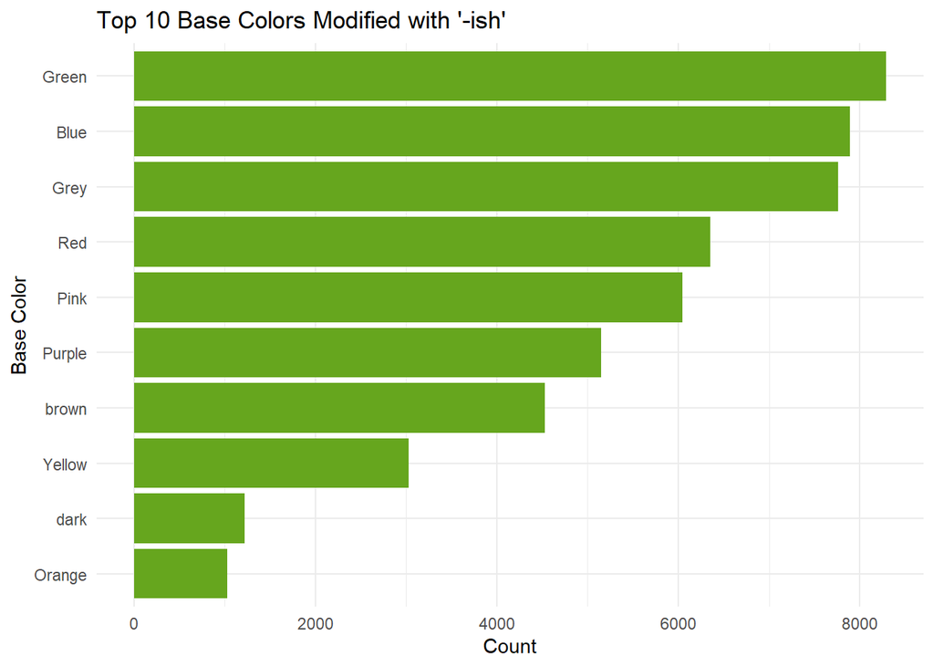

```r
ish_colors |>
  count(base_color) |>
  slice_max(n,
            n = 10) |>
  ggplot(aes(x = reorder(base_color,
                         n), y = n)) +
  geom_col(fill = "#66A61E") +
  coord_flip() +
  labs(x = "Base Color",
       y = "Count",
       title = "Top 10 Base Colors Modified with '-ish'") +
    scale_x_discrete(labels = c("blue" = "Blue",
    "red" = "Red",
    "grey" = "Grey",
    "green" = "Green",
    "purple" = "Purple",
    "orange" = "Orange",
    "yellow" = "Yellow",
    "tan" = "Tan",
    "pink" = "Pink",
    "gold" = "Gold",
    "silver" = "Silver",
    "black" = "Black")) +
  theme_minimal()
```

This chart shows how often each color had “ish”. We can see that the most popular color to be used was `Green`, `Blue`, `Grey`, and `Red`. It is interesting to note that the RGB colors are in the top few colors that are used with “ish”. This could be because they are more common colors that people base other colors off of.

## Color Distance Analysis

```r
reference_hex <- c(blue = "#0000FF",
                   pink = "#FFC0CB",
                   purple = "#800080",
                   red = "#FF0000",
                   green = "#008000",
                   gray = "#808080",
                   silver = "#C0C0C0",
                   yellow = "#FFFF00",
                   orange = "#FFA500",
                   gold = "#FFD700",
                   black = "#000000")


hex_to_rgb <- function(hex) {
rgb <- col2rgb(hex)
as.numeric(rgb)
}


color_distance <- function(hex1, hex2) {
rgb1 <- hex_to_rgb(hex1)
rgb2 <- hex_to_rgb(hex2)
sqrt(sum((rgb1 - rgb2)^2))
}
```

Here I went to w3schools where I looked at the hexadecimal for colors that look the same across all webpages [^1]. I used their definition for the common ish colors like `green`, `blue`, and `pink` were very common. So I went and got those hexadecimal codes, and made my own data frame, `reference_hex` to compare against later.

I had to look online how to find the differences, I found a method using Euclidean distance for RGB colors [^2].

```r
ish_colors <- ish_colors |>
  filter(base_color %in% names(reference_hex)) |>
  mutate(ref_hex = reference_hex[base_color],
         color_dist = map2_dbl(color,
                      ref_hex, ~ color_distance(.x, .y)))
```

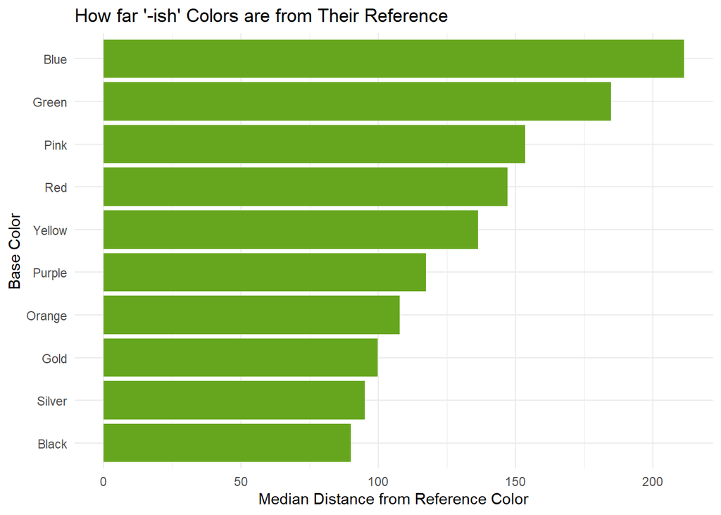

```r
median_distances <- ish_colors |>
  group_by(base_color) |>
  summarise(median_distance = median(color_dist)) |>
  arrange(desc(median_distance))


median_distances |>
  ggplot(aes(x = reorder(base_color,
                         median_distance),
             y = median_distance)) +
  geom_col(fill = "#66A61E") +
  coord_flip() +
  labs(x = "Base Color",
       y = "Median Distance from Reference Color",
       title = "How far '-ish' Colors are from Their Reference") +
  scale_x_discrete(labels = c("blue" = "Blue",
    "red" = "Red",
    "gray" = "Grey",
    "green" = "Green",
    "purple" = "Purple",
    "orange" = "Orange",
    "yellow" = "Yellow",
    "tan" = "Tan",
    "pink" = "Pink",
    "gold" = "Gold",
    "silver" = "Silver",
    "black" = "Black")) +
  theme_minimal()
```

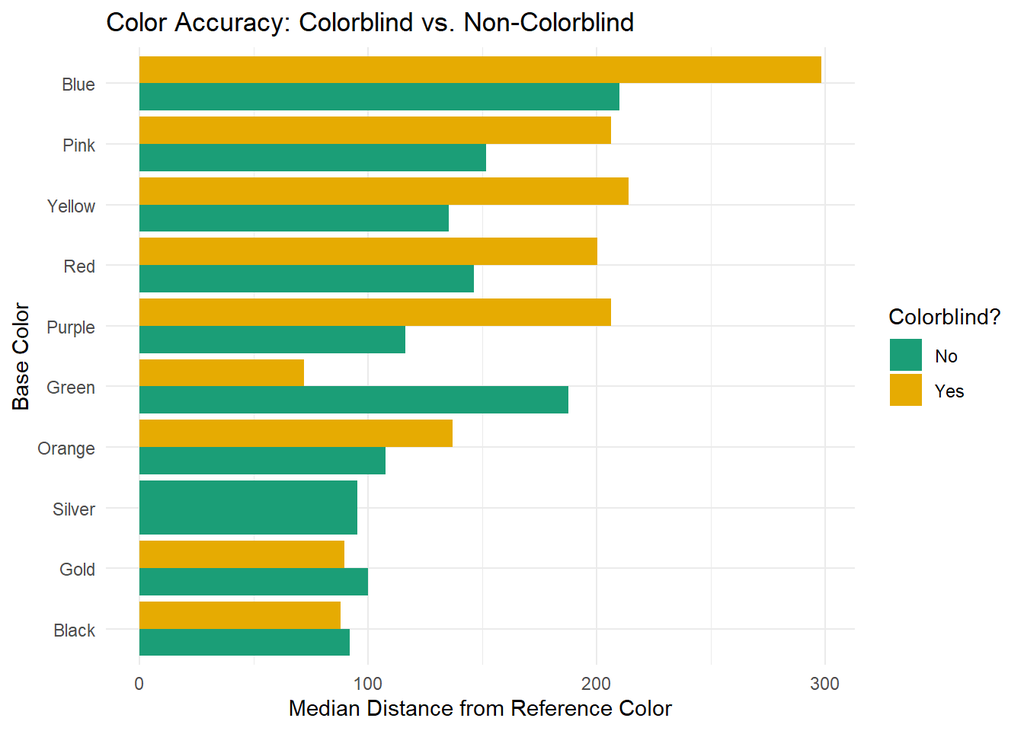

```r
colorblind_comparison <- ish_colors |>
  filter(!is.na(colorblind)) |>
  group_by(base_color,
           colorblind) |>
  summarise(median_distance = median(color_dist))



ggplot(colorblind_comparison, aes(x = reorder(base_color,
                                              median_distance),
                                  y = median_distance,
                                  fill = as.factor(colorblind))) +
  geom_col(position = "dodge") +
  coord_flip() +
  labs(x = "Base Color",
       y = "Median Distance from Reference Color",
       title = "Color Accuracy: Colorblind vs. Non-Colorblind",
       fill = "Colorblind?") +
  scale_fill_manual(values = c("0" = "#1B9E77", "1" = "#E6AB02"),
                    labels = c("No", "Yes")) +
  scale_x_discrete(labels = c("blue" = "Blue",
    "red" = "Red",
    "gray" = "Grey",
    "green" = "Green",
    "purple" = "Purple",
    "orange" = "Orange",
    "yellow" = "Yellow",
    "tan" = "Tan",
    "pink" = "Pink",
    "gold" = "Gold",
    "silver" = "Silver",
    "black" = "Black")) +
  theme_minimal()
```

## Footnotes

[^1]: 1: “HTML Color Names.” W3Schools, https://www.w3schools.com/colors/colors_names.asp . Accessed 22 Oct. 2025.”
[^2]: 2: “Iyer, Luc.”Euclidian Distance in RGB Color Space.” Observable, 6 Feb. 2020, https://observablehq.com/@luciyer/euclidian-distance-in-rgb-color-space . Accessed 22 Oct. 2025.”